# Completed_FullCode_Employee_Promotion_Prediction_Project_3

# ✅ Recommended: **Adaboost with Original Data**

F1: 0.509 (best overall balance)

Precision: 0.878 → very few false promotions

Recall: 0.359 → acceptable capture of deserving employees

Accuracy: 0.941 → robust overall fit

Minimize the risk of unfairly promoting the wrong people, which is crucial in HR-related decisions.

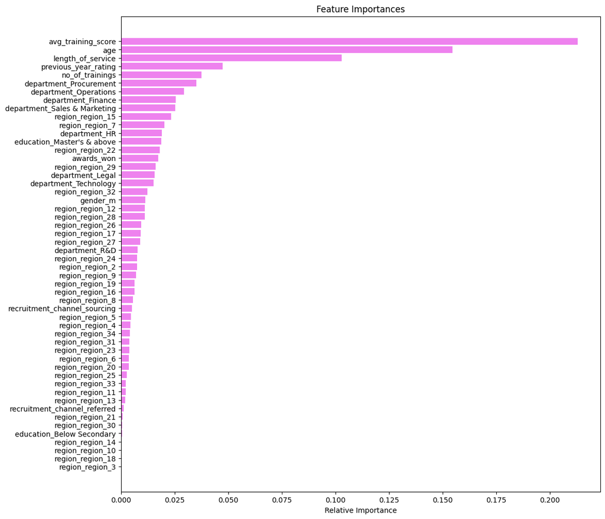

```python
feature_names = X_train.columns

# Check the feature importance of the best model
importances = tuned_adb1.feature_importances_
indices = np.argsort(importances)

plt.figure(figsize=(12, 12))
plt.title("Feature Importances")
plt.barh(range(len(indices)), importances[indices], color="violet", align="center")
plt.yticks(range(len(indices)), [feature_names[i] for i in indices])
plt.xlabel("Relative Importance")
plt.show()
```

- We can see that avg_training_score, age, length_of_service, previous_year_rating, number_of_trainings are the most important features for making predictions.

# Business Insights and Conclusions

Analyzing an employee promotion prediction dataset offers several actionable business insights and conclusions that can help HR departments, business leaders, and organizational strategists make data-informed decisions about talent management.

Performance-Driven Promotions : Employees with higher performance ratings are significantly more likely to be promoted.

Training Impact :Employees who completed relevant training programs and have higher last year score showed a higher probability of promotion.

Experience Matters: Years of service or total work experience positively correlates with promotions

Gender and Diversity Gaps : Gender imbalance or bias might exist if promotion rates are not proportional across genders or minority groups. We have more data for Male employees

These Models can be used as a decision support tool, not a replacement for human judgment.